# Cell type annotation exploration

Data Lab

This notebook explores the use of [`SingleR`](https://bioconductor.org/books/release/SingleRBook/) to perform cell-type annotation on datasets from the ScPCA project SCPCP000007 (Gawad lab data).

**Note:** The first time you run this code it may take a few more minutes due to reference downloads, but they will be cached for faster future execution.

## 0.1 Set Up

```r
knitr::opts_chunk$set(eval=FALSE)
# load the R project
project_root <- here::here()
renv::load(project_root)

suppressPackageStartupMessages({
  library(SingleCellExperiment)
  library(SingleR)
  library(celldex)
  library(ggplot2)
})
theme_set(theme_bw())
set.seed(params$seed) # unclear if this is doing anything? probably not. but maybe later!

utils_dir <- file.path(project_root, "scripts", "utils")

# source the helper functions to grab the integration method check
source(file.path(utils_dir, "integration-helpers.R"))

gawad_project_id <- "SCPCP000007"
sce_file_suffix <- "processed_citeseq.rds"
```

Read in the data:

```r
library_metadata_df <- readr::read_tsv(params$library_file)
# Define the SCE filenames
sce_file_paths <- library_metadata_df %>%
  dplyr::filter(project_name == gawad_project_id) %>%
  dplyr::mutate(sce_file_path = file.path(
    integration_input_dir, sample_biomaterial_id, glue::glue("{library_biomaterial_id}_{sce_file_suffix}")
  )) %>%
  dplyr::pull(sce_file_path)
```

To build an initial sense of what we can expect annotating with `SingleR`, let’s just look at one SCE (arbitrarily chosen as the first):

```r
# For now let's just explore one!
sce_file <- sce_file_paths[[1]]

sce <- readr::read_rds(sce_file)
sce
```

The `celldex` package contains bulk RNA-Seq datasets for use as reference. Since this is AML data, we’ll want a reference that has a lot of blood information. According to the [`celldex`](https://bioconductor.org/packages/release/data/experiment/vignettes/celldex/inst/doc/userguide.html), the `Human Primary Cell Atlas` data will be our closest match.

> The HPCA reference consists of publicly available microarray datasets derived from human primary cells (Mabbott et al. 2013). Most of the labels refer to blood subpopulations but cell types from other tissues are also available.

```r
# define reference with ensembl IDs to match our IDs
ref_se <- celldex::HumanPrimaryCellAtlasData(ensembl = TRUE)

# Predict cell types
#  If we change to `labels = ref_se$label.fine`, we'll get more
#  fine-grained annotations with subtypes etc.
preds_hpca <- SingleR::SingleR(
  # dataset we want to annotate
  test = sce,
  # reference dataset
  ref = ref_se,
  # label.main is broad
  labels = ref_se$label.main)


# Results into a tibble:
preds_df <- tibble::as_tibble(preds_hpca$labels) %>%
  dplyr::rename(celltype = value) %>%
  dplyr::mutate(cell_barcode = rownames(preds_hpca),
                reference = "hpca")

# Save the celltypes:
hpca_celltypes <- unique(ref_se$label.main)
```

```r
SingleR::plotScoreHeatmap(preds_hpca)
```

[output not shown]

But can’t hurt to see how this compares to the `Blueprint/ENCODE` reference:

> The Blueprint/ENCODE reference consists of bulk RNA-seq data for pure stroma and immune cells generated by Blueprint (Martens and Stunnenberg 2013) and ENCODE projects (The ENCODE Project Consortium 2012).

```r
# define reference with ensembl IDs to match our IDs
ref_se <- celldex::BlueprintEncodeData(ensembl = TRUE)

# Predict cell types, broadly
preds_blue_enc <- SingleR::SingleR(
  # dataset we want to annotate
  test = sce,
  # reference dataset
  ref = ref_se,
  # label.main is broad
  labels = ref_se$label.main)


# Results into a tibble:
preds_df <- preds_df %>%
  dplyr::bind_rows(
    tibble::as_tibble(preds_blue_enc$labels) %>%
    dplyr::rename(celltype = value) %>%
    dplyr::mutate(cell_barcode = rownames(preds_blue_enc),
                  reference = "blueprint_encode")
  )

# Save the celltypes:
blueprint_celltypes <- unique(ref_se$label.main)

# And the heatmap:
SingleR::plotScoreHeatmap(preds_blue_enc)
```

[output not shown]

```r
# How many of each celltype?
preds_df %>%
  dplyr::filter(reference == "hpca") %>%
  dplyr::count(celltype) %>%
  dplyr::arrange(-n)


preds_df %>%
  dplyr::filter(reference == "blueprint_encode") %>%
  dplyr::count(celltype) %>%
  dplyr::arrange(-n)
```

For a clearer comparison, we’ll harmonize predicted celltypes, but let’s just focus on exactly matching celltypes as a start -

```r
# Let's see what we have here:
sort(hpca_celltypes)
sort(blueprint_celltypes)

# Manually compiled data rame of celltypes roughly present in BOTH references
#  for now leaving the Pre/Pro B-cells out
shared_celltypes_df <- tibble::tribble(
  ~hpca_celltype, ~blueprint_celltype,
  # Both references have it:
  "Astrocyte", "Astrocytes",
  "B_cell", "B-cells",
  "Chondrocytes","Chondrocytes",
  "DC", "DC",
  "Endothelial_cells", "Endothelial cells",
  "Epithelial_cells", "Epithelial cells",
  "Fibroblasts", "Fibroblasts",
  "Keratinocytes", "Keratinocytes",
  "Macrophage", "Macrophages",
  "Monocyte", "Monocytes",
  "Neurons", "Neurons",
  "Neutrophils", "Neutrophils",
  "NK_cell", "NK cells",
  "Smooth_muscle_cells", "Smooth muscle",
  # two groups - collapse back to overall T cells
  "T_cells", "CD8+ T-cells",
  "T_cells", "CD4+ T-cells",
  # two groups of HSCs, again, collapse back to overall
  "HSC_-G-CSF", "HSC",
  "HSC_CD34+", "HSC"
) %>%
  dplyr::mutate(harmonized_celltype = ifelse(blueprint_celltype == "HSC",
                                             blueprint_celltype,
                                             hpca_celltype))

harmonize_celltypes <- function(preds_df, reference_name) {
  if (reference_name == "hpca") {
    shared_celltypes_colname <- rlang::sym("hpca_celltype")
  } else {
    shared_celltypes_colname <- rlang::sym("blueprint_celltype")
  }

  filtered_preds_df <- preds_df %>%
    dplyr::filter(reference == reference_name)

  sym_reference_name <- rlang::sym(reference_name)
  filtered_preds_df %>%
    dplyr::inner_join(
      dplyr::select(
        shared_celltypes_df,
        celltype = {{shared_celltypes_colname}},
        harmonized_celltype
      )
    ) %>%
    dplyr::select(cell_barcode, {{sym_reference_name}} := harmonized_celltype) %>%
    dplyr::right_join(filtered_preds_df) %>%
    dplyr::mutate({{reference_name}} := dplyr::if_else(
      {{sym_reference_name}} %in% shared_celltypes_df$harmonized_celltype,
      {{sym_reference_name}},
      celltype
    )) %>%
    dplyr::select(-celltype, -reference)
  }

preds_df_harmonized <- harmonize_celltypes(preds_df, "blueprint_encode") %>%
  dplyr::left_join(
    harmonize_celltypes(preds_df, "hpca")
  )

# How often do they match?

preds_df_harmonized %>%
  dplyr::summarize(percent_same = sum(blueprint_encode == hpca) / dplyr::n() )


# Where do they not match?
preds_df_harmonized %>%
  dplyr::filter(hpca != blueprint_encode)

# Are there specific combinations that get differently annotated?
preds_df_harmonized %>%
  dplyr::filter(hpca != blueprint_encode) %>%
  dplyr::select(-cell_barcode) %>%
  dplyr::count(blueprint_encode, hpca) %>%
  dplyr::arrange(-n)
```

## 0.2 Let’s get to it

Now, let’s do cell type annotation with the given reference in `params$reference` on each of the Gawad libraries and look at their UMAPs colored by celltype.

```r
if (params$reference == "hpca") {
  ref_data <- celldex::HumanPrimaryCellAtlasData(ensembl = TRUE)
} else if (params$reference == "blueprint_encode") {
  ref_data <- celldex::BlueprintEncodeData(ensembl = TRUE)
} else {
  stop("Bad reference parameter; either 'hpca' or 'blueprint_encode'.")
}
```

[output not shown]

```
## see ?celldex and browseVignettes('celldex') for documentation
```

```
## loading from cache
```

```
## see ?celldex and browseVignettes('celldex') for documentation
```

```
## loading from cache
```

[output not shown]

```
## loading from cache
```

```
## require("ensembldb")
```

```r
annotate_SingleR <- function(sce, ref_data) {
  # return updated sce and the predictions themselves

  preds <- SingleR::SingleR(
    test = sce,
    ref = ref_data,
    labels = ref_data$label.main
  )

  # Add `pruned.labels`, where low-confidence annotations are NA, to sce
   sce$SingleR_annotations <- preds$pruned.labels

   return(
     list(
       sce = sce,
       preds = preds
       )
   )
}

plot_SingleR <- function(annotation_output) {
  # annotation_output: list of sce and preds
  # Make a heatmap and UMAP and print out

  heatmap <- SingleR::plotScoreHeatmap(annotation_output[["preds"]],
                                       # default but let's be explicit
                                       show.pruned = FALSE)


  umap_df <- tibble::as_tibble(reducedDim(annotation_output[["sce"]], "UMAP")) %>%
    dplyr::select(UMAP1 = V1, UMAP2 = V2) %>%
    dplyr::mutate(celltypes = annotation_output[["sce"]]$SingleR_annotations)

  # We would probably like a more principled approach to colors that is
  #  actually based on biological information about celltypes
  plot_colors <- rainbow( length(unique(umap_df$celltypes[!(is.na(umap_df$celltypes))])))

  umap <- ggplot(umap_df) +
    aes(x = UMAP1, y = UMAP2, color = celltypes) +
    geom_point(size = 0.2, alpha = 0.5) +
    scale_color_manual(values = plot_colors)

  print(heatmap)
  print(umap)

}

run_SingleR <- function(sce_path) {
  print(sce_path)
  sce <- readr::read_rds(sce_path)
  annotate_SingleR(sce, ref_data) %>%
    plot_SingleR()
}
```

Here we go!

```r
purrr::walk(sce_file_paths, run_SingleR)
```

```
## [1] "results/scpca/citeseq_sce/SCPCS000221/SCPCL000295_processed_citeseq.rds"
```

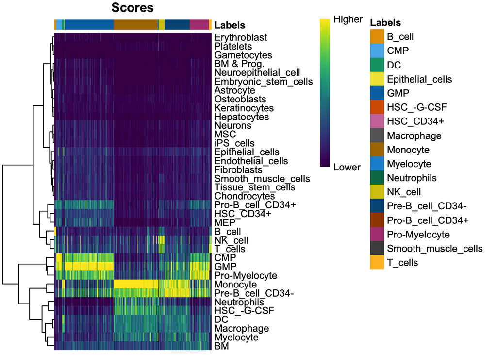

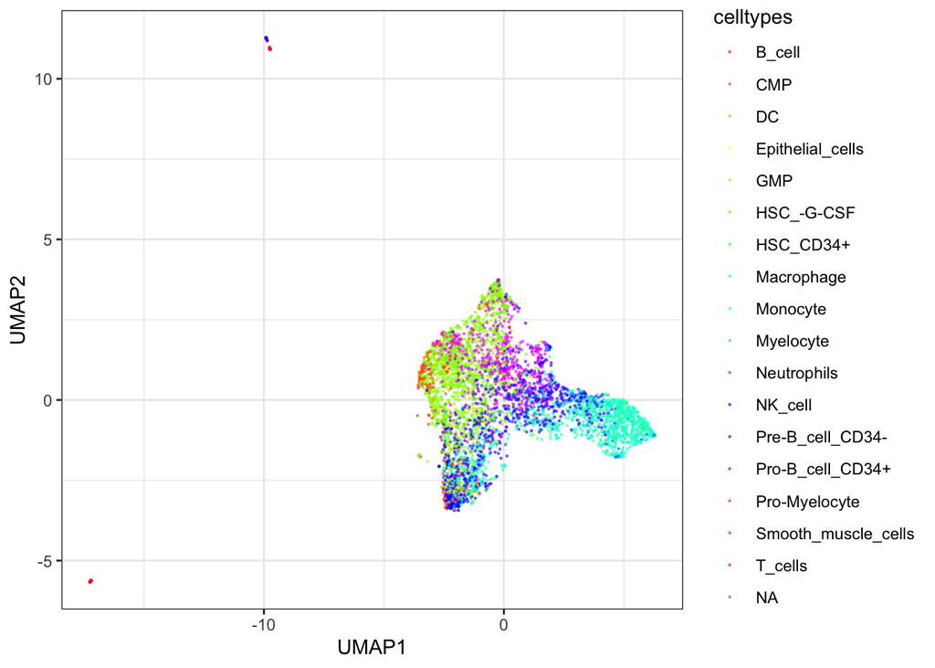

```
## [1] "results/scpca/citeseq_sce/SCPCS000222/SCPCL000296_processed_citeseq.rds"
```

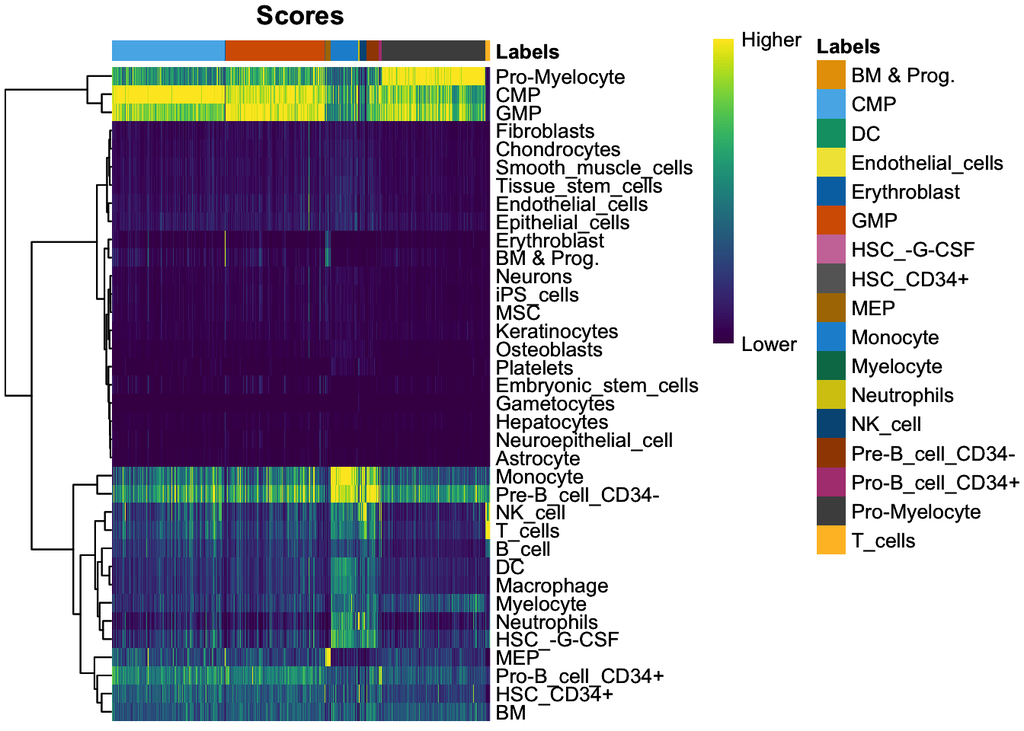

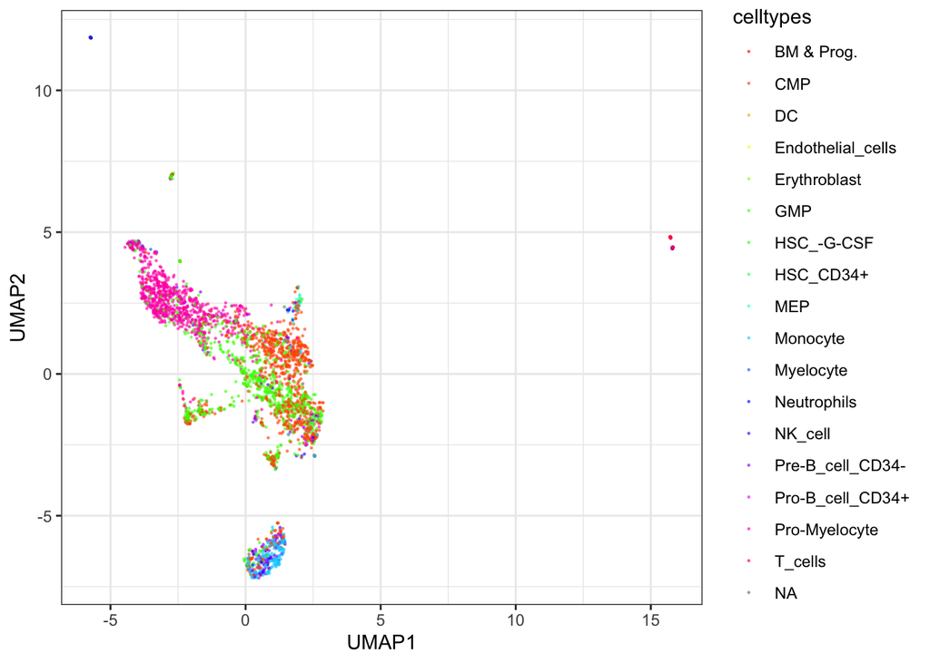

```
## [1] "results/scpca/citeseq_sce/SCPCS000223/SCPCL000297_processed_citeseq.rds"
```

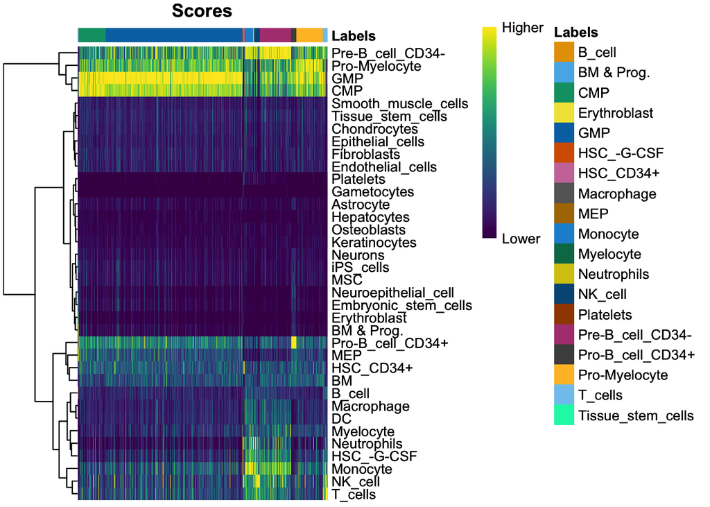

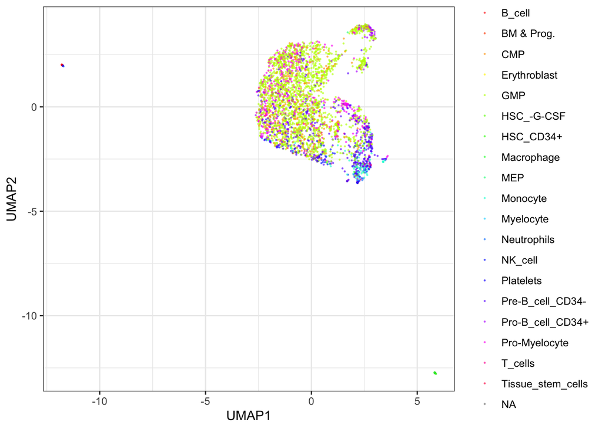

```
## [1] "results/scpca/citeseq_sce/SCPCS000224/SCPCL000298_processed_citeseq.rds"
```

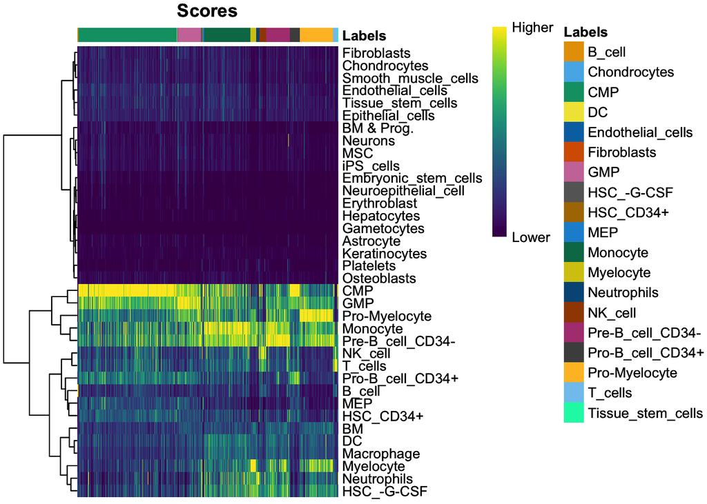

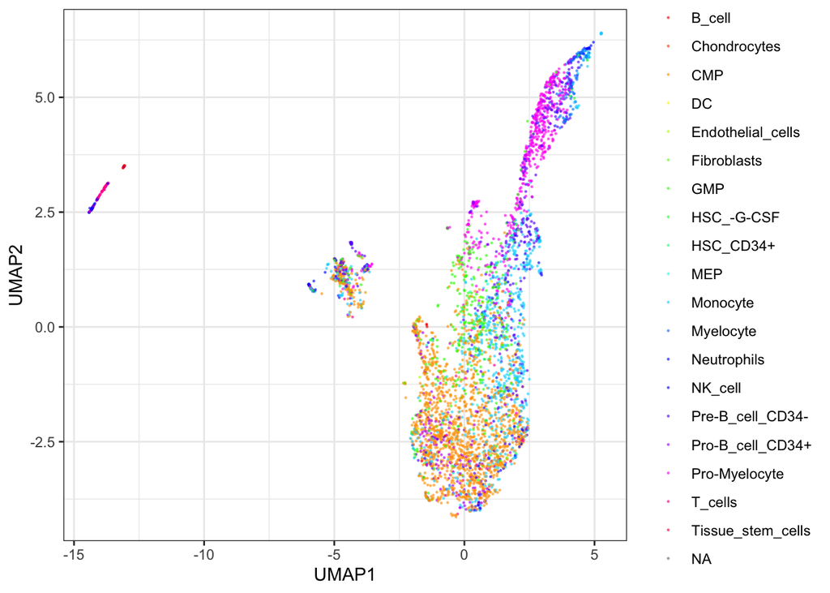

```
## [1] "results/scpca/citeseq_sce/SCPCS000225/SCPCL000299_processed_citeseq.rds"
```

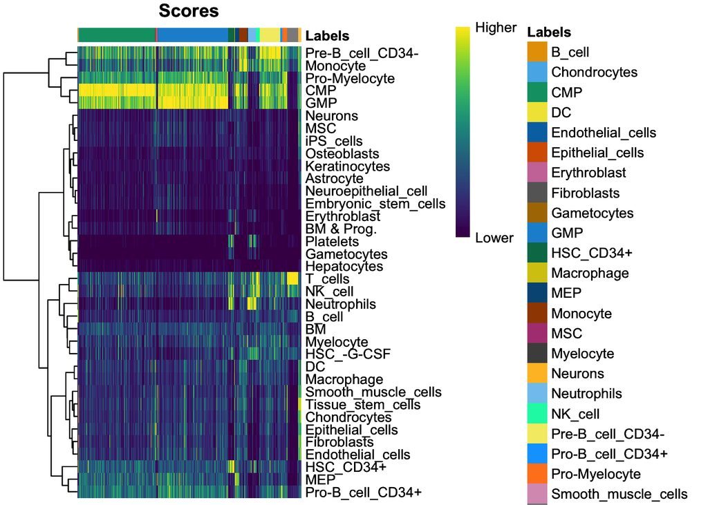

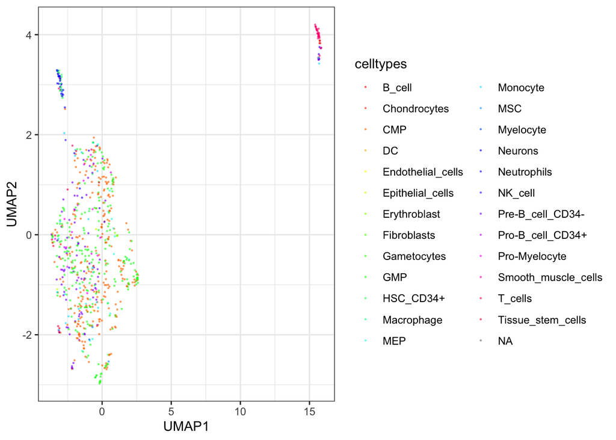